# Designing a Machine Learning Algorithm: A Step-By-Step Guide

Machine Learning on Vehicle Accident Statistics

Fall 2024 Data Science Project

Molly McPoland, Shengquan(Aiden) Yang, Imaan Saadat-Zia, Meklit Assefa, Sharon Oh

Contributions:

- Molly-Dataset Curation and Preprocessing, Data Exploration and Summary Statistics, Final Tutorial Report Creation
  - Set up dataset import, created pandas dfs, eliminated unnecessary data, looked at important data features, and combined accident, person, and vehicle dfs. Determined independent and dependent variables and prepared dataset and X, y for ML portion and provided summaries for actions in each section for tutorial.
- Shengquan Yang-Data Exploration, ML Algorithm Training and Test Data Analysis, Visualization
  - Created the second hypothesis test, helped set up data for ML models, made some graphs such as the heatmap, bar charts, etc. before starting machine learning
- Imaan-Data Exploration, ML Algorithm Design/Development, ML Algorithm Training and Test Data Analysis
  - Created the first hypothesis test, helped set up data for ML models, separated training data and test data, performed k-folds cross-validation for KNN, DecisionTree, LogisticRegression, and RandomForest models, showed accuracies and confusion matrices of each of these models.
- Meklit-Project Idea, Data Exploration, ML Algorithm Design/Development, ML Algorithm Training and Test Data Analysis, Visualization, Results Analysis
  - Came up with the project idea and found the dataset. Created the third hypothesis test, the Random Forest model, plotted the confusion matrix, plotted the decision tree and wrote summaries that explained the results of the matrix and decision tree.
- Sharon-Data Exploration and Summary Statistics, Result Analysis, Conclusion, Final Tutorial Report Creation
  - Wrote the background and reasoning of choosing this dataset. Found conclusions after three hypothesis tests and created conclusion of the final project. Created and formatted information on the Github statically hosted page.

This guide will run you through the major steps of designing a machine leanring algorithm. We will cover:

1. Picking a dataset
2. Exploring and standardizing a dataset
3. Making inital tests
4. Deciding the features of our algorithm
5. Implementing our algorithm
6. Evaluating our algorithm

# Picking Our Dataset

Link to download files: https://www.kaggle.com/datasets/jonbown/us-2020-traffic-accidents

We chose this dataset because it offers a lot of insight on US Traffic Accidents and the various factors that contribute to accidents. The dataset contains many columns detailing the different aspects of an accident such as driver age, weather conditions, and alcohol impairment that will provide a strong foundation for our analysis. With the ever growing number of drivers, we think it is crucial to understand how certain factors contribute to the severity of an accident. We also hope that our study can increase the public's awareness of common characteristics of accidents.

We've also choosen this dataset because it has recent and reliable data, and allows us to make a prediction algorithm for important issues related to traffic safety. A good dataset will be clean, consistent, and easy to understand.

Accident_XX (XX = 16, 17, 18, 19, 20) contains all the information with all the accidents throughout the years. For example, it will contain data on the casenum, total number of vehicles involved in the accident, number of pedestrians involved, date, time, alcohol involvement, and more.

Person_XX (XX = 16, 17, 18, 19, 20) contains all the information involving the people. It will have details on casenum, age, seat position, airbag, ejection, alcohol status, drug status, weight, manner of collision, and more.

Vehicle_XX (XX = 16, 17, 18, 19, 20) contains information about the vehicle. More specifically, the vehicle number in the casenum, if it had rolled over, if the vehicle was towed, if there was a fire, and more.

The different dataframes are connected by the casenum identifier.

Within the datasets, we have many different examples and variables within the 5 years of data provided. Sometimes the data has overlapped within dataframes, however it seems as though since every row has a casenum as their specific identifier it helps remove the duplicates.

Some conclusions that we can test include: Does hour in the day correlate with alcohol involvement? Is there a relationship between weather and severity. Does age impact the accident? We find with these conclusions using the different tests.

# Setup

Libraries and Other Setup

```python
import pandas as pd
import matplotlib.pyplot as plt
import numpy as np
import scipy.stats as sp
from scipy.stats import pearsonr
import seaborn as sns
from scipy.stats import chi2_contingency

pd.set_option('display.max_rows', 400)
pd.set_option('display.max_columns', 400)
```

Create DataFrame for each .csv file

```python
accident_data2016 = pd.read_csv('acc_16.csv')
accident_data2017 = pd.read_csv('acc_17.csv')
accident_data2018 = pd.read_csv('acc_18.csv')
accident_data2019 = pd.read_csv('acc_19.csv', dtype={'CF3': int})
accident_data2020 = pd.read_csv('acc_20.csv')
personal_data2016 = pd.read_csv('pers_16.csv')
personal_data2017 = pd.read_csv('pers_17.csv')
personal_data2018 = pd.read_csv('pers_18.csv')
personal_data2019 = pd.read_csv('pers_19.csv', encoding='cp1252')
personal_data2020 = pd.read_csv('pers_20.csv', encoding='cp1252')
vehicle_data2016 = pd.read_csv('veh_16.csv')
vehicle_data2017 = pd.read_csv('veh_17.csv')
vehicle_data2018 = pd.read_csv('veh_18.csv')
vehicle_data2019 = pd.read_csv('veh_19.csv', encoding='cp1252')
vehicle_data2020 = pd.read_csv('veh_20.csv', encoding='cp1252')
```

Looking at DFs

```python
accident_data2019.dtypes
```

|  | 0 |
| --- | --- |
| CASENUM | int64 |
| STRATUM | int64 |
| STRATUMNAME | object |
| REGION | int64 |
| REGIONNAME | object |
| PSU | int64 |
| PJ | int64 |
| PSU_VAR | int64 |
| URBANICITY | int64 |
| URBANICITYNAME | object |
| VE_TOTAL | int64 |
| VE_FORMS | int64 |
| PVH_INVL | int64 |
| PEDS | int64 |
| PERMVIT | int64 |
| PERNOTMVIT | int64 |
| NUM_INJ | int64 |
| NUM_INJNAME | object |
| MONTH | int64 |
| MONTHNAME | object |
| YEAR | int64 |
| YEARNAME | int64 |
| DAY_WEEK | int64 |
| DAY_WEEKNAME | object |
| HOUR | int64 |
| HOURNAME | object |
| MINUTE | int64 |
| MINUTENAME | object |
| HARM_EV | int64 |
| HARM_EVNAME | object |

[output cut: 58 more lines]

**dtype:** object

Make 1 DF for each year, combining on the CASENUM as reccomended by the kaggle download.

```python
data_2016 = accident_data2016.merge(personal_data2016, on='CASENUM', how='inner').merge(vehicle_data2016, on='CASENUM', how='inner')
data_2017 = accident_data2017.merge(personal_data2017, on='CASENUM', how='inner').merge(vehicle_data2017, on='CASENUM', how='inner')
data_2018 = accident_data2018.merge(personal_data2018, on='CASENUM', how='inner').merge(vehicle_data2018, on='CASENUM', how='inner')
data_2019 = accident_data2019.merge(personal_data2019, on='CASENUM', how='inner').merge(vehicle_data2019, on='CASENUM', how='inner')
data_2020 = accident_data2020.merge(personal_data2020, on='CASENUM', how='inner').merge(vehicle_data2020, on='CASENUM', how='inner')
```

```python
print(data_2016.shape, data_2017.shape, data_2018.shape, data_2019.shape, data_2020.shape)
```

```
(234169, 197) (276909, 197) (239343, 190) (268619, 353) (256742, 349)
```

We can see that there are far more features in 2019 and 2020, so we will need to trim down our data to a more manageable size.

```python
print(data_2016.isna().sum())
```

```
CASENUM            0
PSU_x              0
PJ_x               0
STRATUM_x          0
VE_TOTAL           0
VE_FORMS_x         0
PVH_INVL           0
PEDS               0
PERMVIT            0
PERNOTMVIT         0
NUM_INJ            0
MONTH_x            0
YEAR               0
DAY_WEEK           0
HOUR_x             0
MINUTE_x           0
HARM_EV_x          0
ALCOHOL            0
MAX_SEV            0
MAN_COLL_x         0
RELJCT1            0
RELJCT2            0
TYP_INT            0
WRK_ZONE           0
REL_ROAD           0
LGT_COND           0
WEATHER1           0
WEATHER2           0
WEATHER            0
SCH_BUS_x          0
INT_HWY            0
CF1                0
CF2                0
CF3                0
WKDY_IM            0
HOUR_IM            0
MINUTE_IM          0
EVENT1_IM          0
MANCOL_IM          0
RELJCT1_IM         0
```

[output cut: 143 more lines]

```
HITRUN_IM          0
BDYTYP_IM          0
MDLYR_IM           0
IMPACT1_IM         0
VEVENT_IM          0
PCRASH1_IM         0
MXVSEV_IM          0
NUMINJ_IM          0
V_ALCH_IM          0
URBANICITY         0
REGION             0
PSUSTRAT           0
PSU_VAR            0
WEIGHT             0
dtype: int64
```

We can see we are missing very few values, so we can just concerntrate our analysis on the features we have all the data for.

Dropping repeating and uneccesary columns.

```python
data_2016.drop(data_2016.filter(regex='_y$').columns, axis=1, inplace=True)
data_2016.drop(data_2016.filter(regex='_x$').columns, axis=1, inplace=True)
data_2017.drop(data_2017.filter(regex='_y$').columns, axis=1, inplace=True)
data_2017.drop(data_2017.filter(regex='_x$').columns, axis=1, inplace=True)
data_2018.drop(data_2018.filter(regex='_y$').columns, axis=1, inplace=True)
data_2018.drop(data_2018.filter(regex='_x$').columns, axis=1, inplace=True)
data_2019.drop(data_2019.filter(regex='_y$').columns, axis=1, inplace=True)
data_2019.drop(data_2019.filter(regex='_x$').columns, axis=1, inplace=True)
data_2019.drop(['NUM_INJNAME', 'YEARNAME', 'DAY_WEEKNAME', 'HOUR_IMNAME', 'MINUTE_IMNAME', 'AGENAME', 'AGE_IM', 'AGE_IMNAME', 'SEX_IM', 'SEX_IMNAME', 'MONTHNAME', 'HOURNAME', 'MINUTENAME', 'DR_ZIPNAME', 'LGTCON_IMNAME', 'LGTCON_IM', 'MAXSEV_IM', 'MAXSEV_IMNAME'], axis=1, inplace=True)
data_2020.drop(data_2020.filter(regex='_y$').columns, axis=1, inplace=True)
data_2020.drop(data_2020.filter(regex='_x$').columns, axis=1, inplace=True)
data_2020.drop(['NUM_INJNAME', 'YEARNAME', 'DAY_WEEKNAME', 'HOUR_IMNAME', 'MINUTE_IMNAME', 'AGENAME', 'AGE_IM', 'AGE_IMNAME', 'SEX_IM', 'SEX_IMNAME', 'MONTHNAME', 'HOURNAME', 'MINUTENAME', 'DR_ZIPNAME', 'LGTCON_IMNAME', 'LGTCON_IM', 'MAXSEV_IM', 'MAXSEV_IMNAME'], axis=1, inplace=True)
```

# First Hypothesis Test:

**Per each year:**

H0 = The hour of day when the accident happened does not impact alcohol involvement.

HA = The hour of day when the accident happened does have an impact on alcohol involvement.

```python
# adjust data to only include valid hours and show crosstab
hour_2016 = data_2016.query('Hour >= 0' and 'HOUR <= 24')
tab_2016 = pd.crosstab(hour_2016['HOUR'], hour_2016['ALCOHOL'])
tab_2016
```

| ALCOHOL HOUR | 1 | 2 | 8 | 9 |
| --- | --- | --- | --- | --- |
| 0 | 535 | 1561 | 0 | 477 |
| 1 | 416 | 966 | 2 | 396 |
| 2 | 537 | 831 | 1 | 315 |
| 3 | 380 | 710 | 0 | 202 |
| 4 | 164 | 729 | 0 | 277 |
| 5 | 129 | 1703 | 0 | 367 |
| 6 | 76 | 4391 | 0 | 855 |
| 7 | 75 | 10233 | 0 | 1151 |
| 8 | 80 | 10290 | 0 | 1274 |
| 9 | 99 | 8172 | 0 | 1088 |
| 10 | 104 | 8322 | 0 | 984 |
| 11 | 171 | 10448 | 0 | 1229 |
| 12 | 144 | 12990 | 2 | 1787 |
| 13 | 155 | 12756 | 0 | 1608 |
| 14 | 196 | 14112 | 0 | 1740 |
| 15 | 302 | 18679 | 0 | 2581 |
| 16 | 423 | 18601 | 0 | 2470 |
| 17 | 501 | 20783 | 0 | 2651 |
| 18 | 657 | 13737 | 1 | 2253 |
| 19 | 650 | 9131 | 3 | 1609 |
| 20 | 671 | 6639 | 0 | 1308 |
| 21 | 907 | 4786 | 0 | 1128 |
| 22 | 547 | 3335 | 0 | 907 |
| 23 | 490 | 2423 | 0 | 563 |

```python
# group each level of alcohol involvment
# since 3, 4, 5, 6, and 7 alcohol levels are empty, we only need:
impact_9_2016 = hour_2016[hour_2016['ALCOHOL'] == 9]
impact_8_2016 = hour_2016[hour_2016['ALCOHOL'] == 8]
impact_2_2016 = hour_2016[hour_2016['ALCOHOL'] == 2]
impact_1_2016 = hour_2016[hour_2016['ALCOHOL'] == 1]
```

```python
# Use an ANOVA test to find the p-value
sp.f_oneway(impact_9_2016['HOUR'], impact_8_2016['HOUR'], impact_2_2016['HOUR'], impact_1_2016['HOUR'])
```

```
F_onewayResult(statistic=4.305566042983962, pvalue=0.004820996977579014)
```

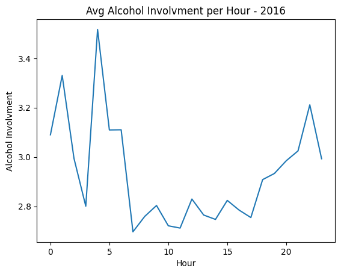

```python
# graph
hour_2016_group = hour_2016.groupby('HOUR')
hour_2016_group.first()
alc_mean_2016 = hour_2016_group['ALCOHOL'].mean()
alc_mean_2016.plot(title = 'Avg Alcohol Involvment per Hour - 2016', xlabel= 'Hour', ylabel= 'Alcohol Involvment')
```

Because the p-value (0.0048) is less than 𝛼 (assuming 𝛼 = 0.05), we should reject the null hypothesis for this year. The graph also supports this as there is a clear peak in alcohol involvment during certain hours.

### We can reject the null hypothesis, meaning that it is not the case that the hour of the day does not impact alcohol involvement.

# Second Correlation and Hypothesis Test:

The goal of this correlation test is to analyze the relationship between age and the number of accidents an individual or group of individuals (in the case of multi-person accidents) is involved in. We aim to determine if there is a significant correlation between a person's age and the likelihood of being involved in accidents.

**Hypothesis**:

H0: There is no correlation between age and the number of accidents. Age does not influence accident involvement.

HA: There is a correlation between age and the number of accidents. Age does influence accident involvement.

```
Correlation: -0.09845508719539112, P-value: 4.105892075953899e-115
```

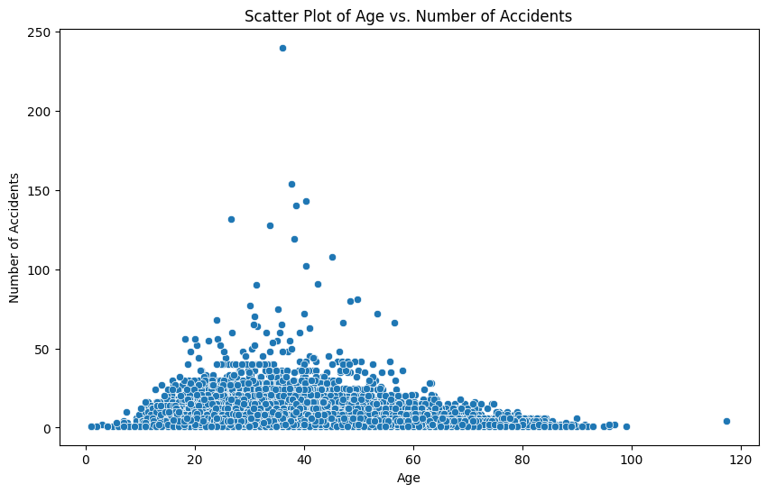

```python
data_filtered = data_2019[(data_2019['AGE'] > 0) & (data_2019['AGE'] <= 150)]

accidents_by_age = data_filtered.groupby('CASENUM').agg({
    'AGE': 'mean',
    'CASENUM': 'size'
}).rename(columns={'CASENUM': 'NUM_ACCIDENTS'})

accidents_by_age = accidents_by_age.dropna(subset=['AGE'])

corr, p_value = pearsonr(accidents_by_age['AGE'], accidents_by_age['NUM_ACCIDENTS'])
print(f'Correlation: {corr}, P-value: {p_value}')

plt.figure(figsize=(10, 6))
sns.scatterplot(x='AGE', y='NUM_ACCIDENTS', data=accidents_by_age)
plt.title('Scatter Plot of Age vs. Number of Accidents')
plt.xlabel('Age')
plt.ylabel('Number of Accidents')
plt.show()
```

The correlation coefficient, -0.09845508719539112, is negative and quite close to zero, indicating a very weak negative correlation between age and the number of accidents.

The p-value, 4.105892075953899e-115, is extremely small, which means the correlation is statistically significant. In other words, there is strong evidence to reject the null hypothesis that age and accident involvement are uncorrelated.

### While the correlation between age and the number of accidents is statistically significant, the weak negative correlation suggests that age has very little practical influence on the likelihood of being involved in an accident. Therefore, age is not a strong predictor of accident involvement, even though there is some evidence of a slight trend toward fewer accidents as age increases. Other factors are likely to play a more substantial role in determining accident rates.

# Third Correlation and Hypothesis Test:

The goal of this correlation test is to analyze the relationship between weather conditions and the severity of an accident and determine if there is a significant correlation between the two.

Hypothesis:

H0: There is no significant relationship between weather conditions and the severity of accidents.

HA: There is a significant relationship between weather conditions and the severity of accidents.

```
Chi Value: 6153.712148220871
P-value: 0.0
```

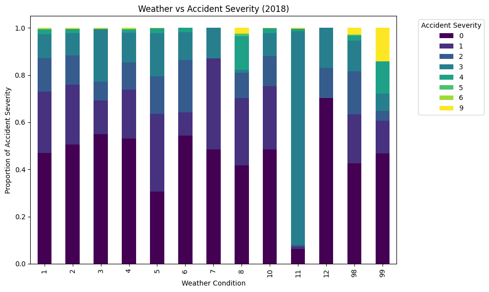

```python
df18_filtered = data_2018[['WEATHER', 'MAX_SEV']]

df18_filtered = df18_filtered.dropna()

contingency_table = pd.crosstab(df18_filtered['WEATHER'], df18_filtered['MAX_SEV'])

chi2, p_value, dof, expected = chi2_contingency(contingency_table)

print(f"Chi Value: {chi2}")
print(f"P-value: {p_value}")


contingency_table_normalized = contingency_table.div(contingency_table.sum(1), axis=0)

contingency_table_normalized.plot(kind='bar', stacked=True, figsize=(10, 6), cmap="viridis")

plt.title('Weather vs Accident Severity (2018)')
plt.xlabel('Weather Condition')
plt.ylabel('Proportion of Accident Severity')
plt.legend(title='Accident Severity', bbox_to_anchor=(1.05, 1), loc='upper left')
plt.tight_layout()
plt.show()
```